# Model Replication

Daniel Gardner

2024-04-01

# Setup

Here I import the model as used in the paper and then create the data frame we will be using throughout the code.

To begin with, I used the model in its BoolNet form (.bnet), as sometimes loading from SBML form was unreliable. However using either `loadNetwork()` for a .bnet file or `loadSBML()` for an .SBML file load the same model. The model consists of a list of three sections:

- `genes`: a character list of all genes (nodes) used in the model
- `fixed`: a vector of all genes to flag whether a gene would be ‘fixed’ during the simulation
- `interactions`: a list of all genes, each containing a list of all the gene’s input nodes, their Boolean rule, and the Boolean rule in truth table format

Using this, I then created a dataset consisting of:

- Genes: the character list of all genes
- Values: The Boolean value of each gene (i.e. 0 or 1)
- Rules: The Boolean rule of each gene, stored as a character of a Boolean rule
- Degree: The number of input nodes going into each gene

I also created an individual Boolean variable for each gene, so this way when using `eval(parse(text=Rule))` , the function returned a Boolean output.

I also made sure to differentiate the input genes, ‘variable genes’ which would change during the time series, and output genes.

First we define a function which takes in a model of `.bnet` format and outputs a data frame we can work with

```r
# DEFINING FUNCTION LOADING DATA

CreateModel<-function(Model){

  # Creating list of genes
  Genes<-Model$genes

  # Counting number of genes
  num.genes<-length(Genes)

  # Creating data frame with Gene Name, Gene boolean value (1 or 0),
  # Gene Rule, and Gene degree
  Data<-data.frame(Genes=Genes,
                   Values=sample(c(0,1),num.genes,replace = T),
                   Rules=rep("none",num.genes),
                   Degree=rep(0,num.genes))

  for (i in 1:num.genes){
    # Creating a boolean variable for each gene,
    # with initial value corresponding to its inital value
    assign(Genes[i],as.logical(Data$Values[i]), envir = parent.frame())
    # Assigning each gene its rule and degree
    Data$Rules[i]<-Model$interactions[[i]][3][[1]]
    Data$Degree[i]<-length(Model$interactions[[i]][1][[1]])
  }

  # Returning data frame
  return(Data)

}
```

Now we have a data frame with all needed information, we can define the method of updating as described in Stoll et. al. (2012). I.e. checking each component to see if an update will change its value, then uniformly picking one of only these components to update at random.

```r
FindStableStates<-function(DataFrame,Input_Genes,num_sims,num_steps){

  # Number of Simulations
  N<-num_sims

  # Maximum number of steps per simulation
  K<-num_steps

  # Defining genes
  Genes<-DataFrame$Genes

  # Defining variable genes
  Variable_Genes<-Genes[!(Genes%in%Input_Genes)]

  # Size of network
  num.genes<-dim(DataFrame)[1]
  L<-num.genes-length(Input_Genes)

  # Checking how many steps are required for convergence
  sims<-c()

  # List of stable state outputs
  Stable_States<-list(rep(NA,N))

  for(j in 1:N){

      go<-TRUE

      #Creating random initial values of ALL genes
      DataFrame$Values<-sample(c(0,1),num.genes,replace=TRUE)

      for (i in 1:num.genes){
      assign(Genes[i],as.logical(DataFrame$Values[i]), envir = parent.frame())
      }

      # Defining time series of JUST the variable genes
      Time_Series<-DataFrame[DataFrame$Genes %in% Variable_Genes,]

    for (k in 1:K){

      sim<-1

      while(go){

            #################         1         #####################
            # Checking which components will change when updated
            # I.e. which state changes are an asynchronous transition

            Does.Change<-rep(FALSE,L)
            for (l in 1:L){

                Gen.act<-eval(parse(text=Time_Series$Rules[l]))
                # If activated and off, change induced
                if (Gen.act & Time_Series$Values[l]==0){
                  Does.Change[l]<-TRUE
              }
                # If repressed and on, change induced
                if(!Gen.act & Time_Series$Values[l]==1){
                  Does.Change[l]<-TRUE
                }

            }

            # Creating list of actual step-specific variable genes
            Step_Variable_Genes<-Variable_Genes[Does.Change]

            #################         2         #####################
            # Now if no genes can change, we are in a steady state and
            # end the simulation. If not, we perform an update

            if(length(Step_Variable_Genes)==0){
              # Log the final value of the chain as the stable state for simulation j
              Stable_States[[j]]<-c(DataFrame$Values[DataFrame$Genes %in% Input_Genes],
                                    Time_Series$Values)
              sims<-append(sims,sim)
              go<-FALSE


            }

            else{

                  ##############        3            ################
                  # Performing the actual updating scheme

                  # Then simply repeat the process as before
                  sim<-sim+1

                  #Uniformly sample gene to update
                  Gene<-sample(Step_Variable_Genes,1)

                  # For the given gene,find its rule, current value,
                  # and whether it is being activated
                  Rule<-DataFrame[DataFrame$Genes==Gene,3]
                  Gen.act<-eval(parse(text=Rule))
                  cur.val<-Time_Series$Values[Time_Series$Genes==Gene]

                  # If activated and off, turn on
                  if (Gen.act & cur.val==0){
                    Time_Series$Values[Time_Series$Genes==Gene]<-1
                    assign(Gene,TRUE, envir = parent.frame())

                }
                  # If repressed and on, turn off
                  else if(!Gen.act & cur.val==1){
                    Time_Series$Values[Time_Series$Genes==Gene]<-0
                    assign(Gene,FALSE, envir = parent.frame())

                  }

                #####################################################

            }

      }

    }

  }

  # Calculating probabilities of each state
  Unique_States<-unique(Stable_States)

  Probs<-c()
  for (stable in Unique_States){
    count<-0
    for (state in Stable_States){
      if (all(state==stable)){
        count <-count +1
      }
    }
    Probs<-append(Probs,count/N)
  }

  # Creating list of named components instead of 1s and 0s
  Named_States<-lapply(Unique_States,
                       function(x){return(c(rev(Input_Genes),
                                            Variable_Genes)[as.logical(x)])})

  # Returning unique stable states and probabilities
  return(list(Unique_States,Named_States,Probs))
}
```

Now to check these results with those of a MaBoSS simulation, we need to import the results, match the stable states to each other, and then plot the corresponding probabilites.

```r
MaBoSS_Comparison<-function(MaBoSS_csv,Named_Stable_States,Probs){

  # Getting probabilities of all stable states
  MaBoSS_Probs<-MaBoSS_csv$Proba

  # Getting all stable states
  MaBoSS_Mat<-subset(MaBoSS_csv,select = -c(FP,Proba,State))
  n<-nrow(MaBoSS_Mat)
  maboss_states<-list(rep(NA,n))

  for(i in 1:n){
    maboss_states[[i]]<-colnames(MaBoSS_Mat)[as.logical(MaBoSS_Mat[i,])]
  }

  # Rearranging states to line up with ours
  new.order<-rep(0,n)
  for (i in 1:n){

    for(j in 1:n){

      if(all(maboss_states[[i]] %in% Named_Stable_States[[j]]) &
         length(maboss_states[[i]])==length(Named_Stable_States[[j]])){

        new.order[j]<-i
      }

    }

  }

  # Plotting our estimated probabilities versus MaBoSS' in red
  PlotData<-data.frame(State=seq(1,n),
                       Probability=c(Probs,MaBoSS_Probs[new.order]),
                       Estimate=c(rep('Mine',n),rep('MaBoSS',n)))

  plot<-ggplot(PlotData,aes(x=as.factor(State),y=Probability,col=Estimate)) +
    geom_point(alpha=.5) +
    theme_light()
  return(plot)

}
```

## Example 1: Cohen Simple Model

To begin we will attempt the simplest model given in Cohen (2015). Using GINsim, the model looks like this,

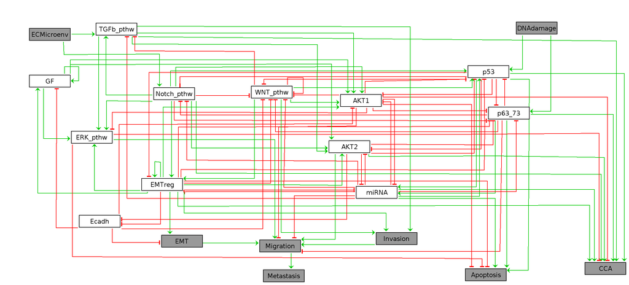

Simplified Cohen model with 20 nodes

```r
library(BoolNet)
library(ggplot2)

# Loading the model in BoolNet (.bnet) format and converting
Cohen_Simple<-CreateModel(loadNetwork('Models/Cohen_Simple/CohenSimpleModel.bnet'))

# Then running simulations
start <- Sys.time()
Cohen_Simple_Sims<-FindStableStates(Cohen_Simple,c('ECMicroenv','DNAdamage'),10000,300)
end<-Sys.time()

print(end-start)
```

```
## Time difference of 52.25736 secs
```

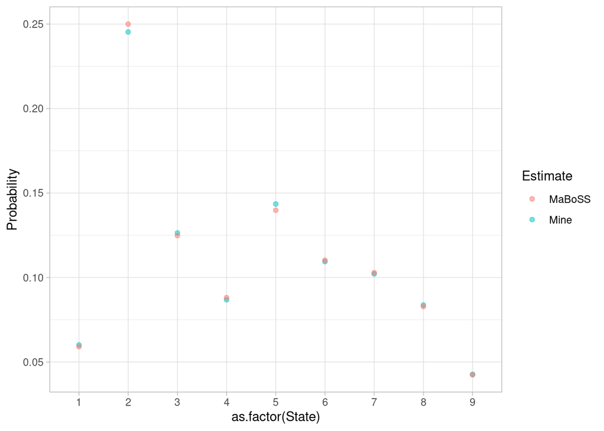

```r
# Then importing MaBoSS results and seeing if ours match
Cohen_Simple_MaBoSS<-read.csv('Models/Cohen_Simple/Cohen_MaBoSS/Cohen_MaBoSS_fp.csv', sep = "\t",skip=1)
MaBoSS_Comparison(Cohen_Simple_MaBoSS,Cohen_Simple_Sims[[2]],Cohen_Simple_Sims[[3]])
```

## Example 2: Cohen Full Model

Now we rerun the analysis, this time on the fully described version of the model in Cohen (2015). As seen here, the model uses the same input and output variables (Except for a slight name change in `CCA` to `CellCycleArrest`), but just with more in-between components. For instance, the `miRNA` component in the simple model has now become three separate components: `miR34`,`miR200`, and `miR203`.

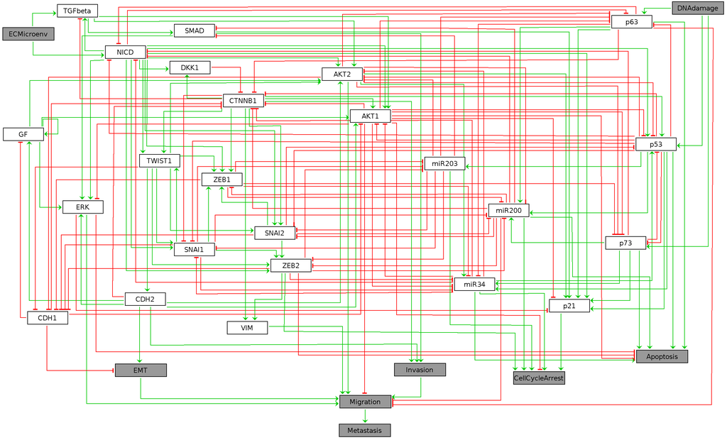

Full Cohen model

```r
# Loading the model in BoolNet (.bnet) format and converting
Cohen_Full<-CreateModel(loadNetwork('Models/Cohen_Full/Cohen_Full.bnet'))

# Then running simulations
start <- Sys.time()
Cohen_Full_Sims<-FindStableStates(Cohen_Full,c('ECMicroenv','DNAdamage'),10000,300)
end <- Sys.time()

print(end-start)
```

```
## Time difference of 2.321321 mins
```

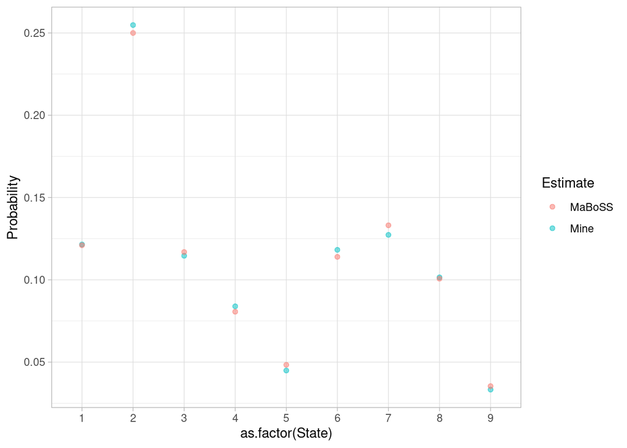

```r
# Then importing MaBoSS results and seeing if ours match
Cohen_Full_MaBoSS<-read.csv('Models/Cohen_Full/Cohen_Full_MaBoSS/Cohen_Full_MaBoSS_fp.csv', sep = "\t",skip=1)
MaBoSS_Comparison(Cohen_Full_MaBoSS,Cohen_Full_Sims[[2]],Cohen_Full_Sims[[3]])
```

## Example 3: Montagud Prostate cancer model

Finally we will experiment with a much larger model published by Montagud et. al. (2022) of prostate cancer. This model now has 11 initial states instead of two as before, and is far more complex.

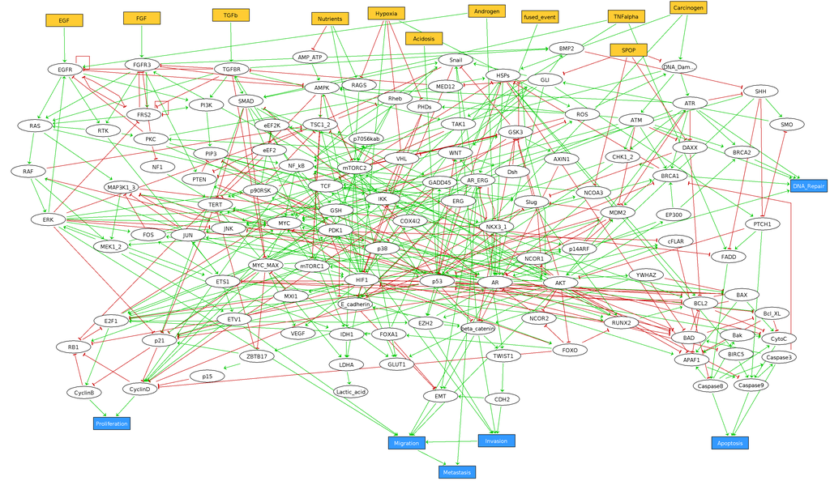

Montagud prostate cancer model

```r
# Loading the model in BoolNet (.bnet) format and converting
Montagud<-CreateModel(loadNetwork('Models/Montagud/Montagud.bnet'))

# Then running simulations
#Montagud_Sims<-FindStableStates(Montagud,c('EGF','FGF','TGFb','Nutrients',
#                                           'Hypoxia','Acidosis','Androgen',
#                                           'fused_event','TNFalpha','SPOP',
#                                           'Carcinogen'),5,300)

# Then importing MaBoSS results and seeing if ours match
#Cohen_Full_MaBoSS<-read.csv('Models/Cohen_Full/Cohen_Full_MaBoSS/Cohen_Full_MaBoSS_fp.csv', sep = "\t",skip=1)
#MaBoSS_Comparison(Cohen_Full_MaBoSS,Cohen_Full_Sims[[2]],Cohen_Full_Sims[[3]])
```